# Creating State Maps

Rachel Carroll, Mazama Science

October 23, 2020

## Objective

The goal of this document is to introduce the `stateMap()` function in the **MazamaSpatialPlots** package. This document will serve as a tutorial for collecting data and creating customizable maps of U.S. states and territories.

## Default Plot

In this example, the package-internal dataframe, `example_US_stateObesity`, is used directly:

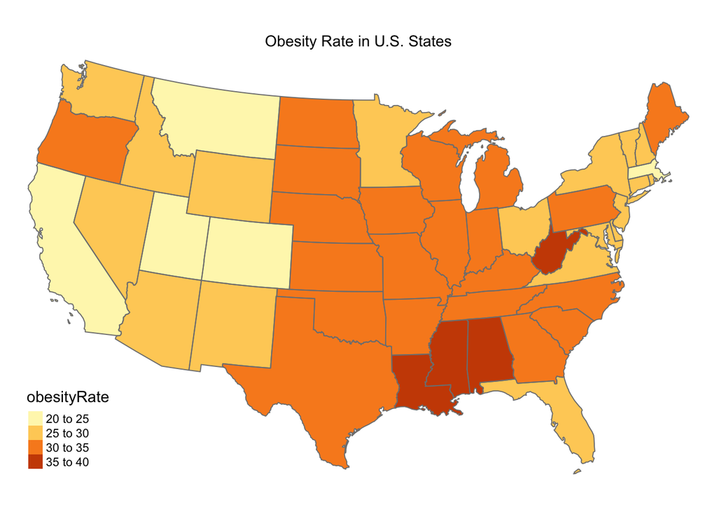

```r
library(MazamaSpatialPlots)

stateMap(
  data = example_US_stateObesity,
  parameter = 'obesityRate',
  title = "Obesity Rate in U.S. States"
)
```

## Customizing with Function Parameters

### Using palette, breaks, and stateBorderColor

The `palette`, `breaks`, and `stateBorderColor` parameters dictate the coloring of your map. The shade(s) are defined with `palette` and the distribution of color across the map is defined with `breaks`.

In this example, `breaks` is used to create a coarser coloring scheme and `palette` is used to customize the exact color for each obesity rate level.

```r
stateMap(
  data = example_US_stateObesity,
  parameter = 'obesityRate',
  palette = c("lightblue", "orange", "red"),
  breaks = c(20, 27, 34, 40),
  stateBorderColor = "black",
  title = "Obesity Rate in U.S. States"
)
```

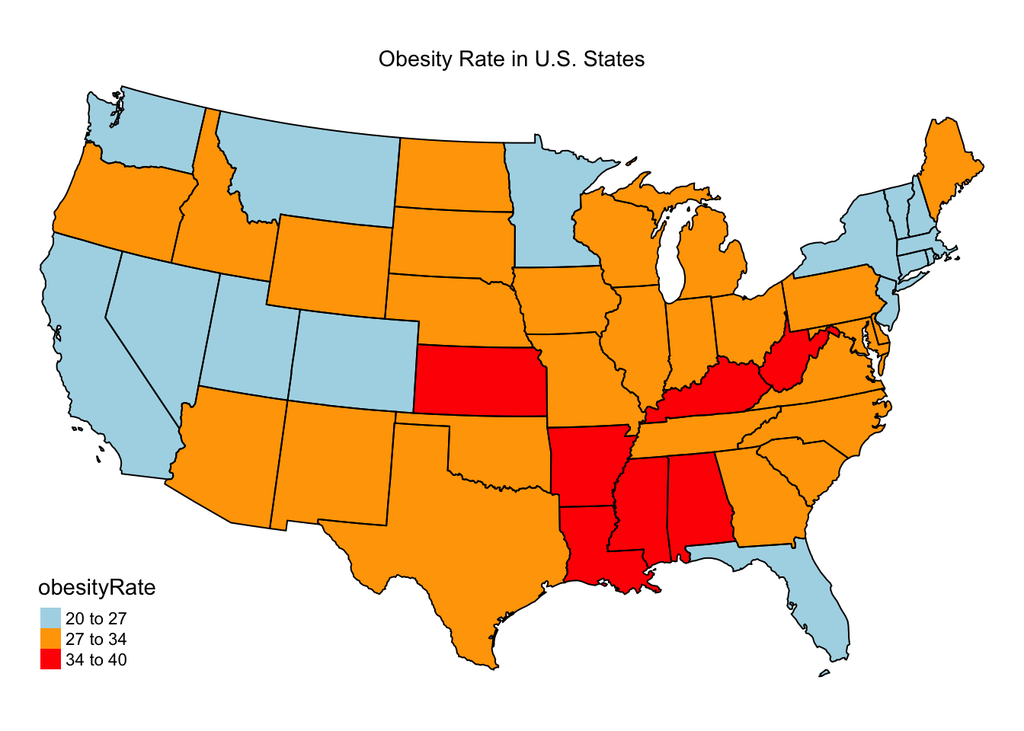

In this example, `breaks` is used to create a more detailed coloring scheme and the blue to purple color palette is chosen.

```r
stateMap(
  data = example_US_stateObesity,
  parameter = 'obesityRate',
  palette = 'BuPu',
  breaks = seq(20, 38, 3),
  stateBorderColor = 'white',
  title = "Obesity Rate in U.S. States"
)
```

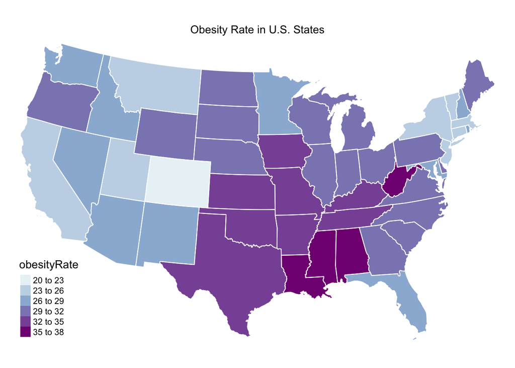

## Customizing with the **tmap** Package

### Using tmap::tm_layout()

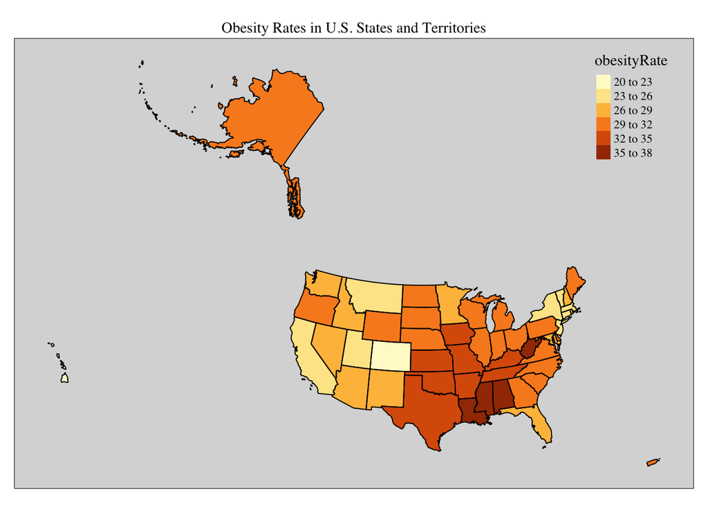

```r
stateMap(
  data = example_US_stateObesity,
  parameter = "obesityRate",
  breaks = seq(20,38,3), #increasing color detail
  conusOnly = FALSE ,
  stateBorderColor = 'black',
) +
  tmap::tm_layout(
    frame = TRUE,
    main.title = 'Obesity Rates in U.S. States and Territories',
    main.title.position = c("center", "top"),
    title.fontface = 2,
    fontfamily = "serif",
    bg.color = "grey85",
    inner.margins  = .05,
    legend.position = c('right', 'top')
  )
```

### Using tmap style “classic” and a compass

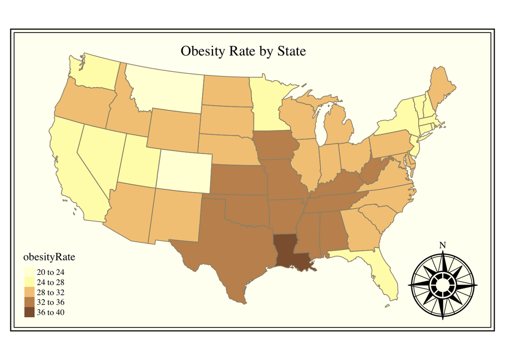

```r
stateMap(
  data = example_US_stateObesity,
  parameter = "obesityRate",
  breaks = seq(20,40,4),
) +
  tmap::tm_style(
    'classic'
  ) +
  tmap::tm_layout(
    title = 'Obesity Rate by State',
    title.position = c("center", "top"),
    title.size = 1.2,
    inner.margins  = .08
  ) +
  tmap::tm_compass()
```

### Polishing New England regional map

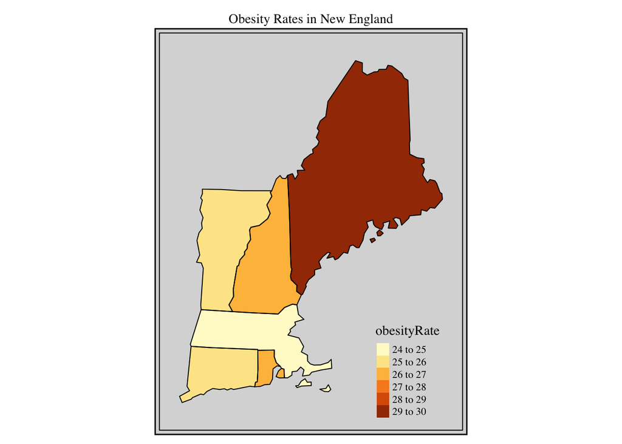

```r
stateMap(
 data = example_US_stateObesity,
 parameter = "obesityRate",
 stateCode = c('ME', 'NH', 'VT', 'MA', 'RI', 'CT'),
 stateBorderColor = 'black',
 title = 'Obesity Rates in New England'
) +
 tmap::tm_layout(
   frame = TRUE,
   frame.double.line = TRUE,
   title.size = 1.2,
   title.fontface = 2,
   fontfamily = "serif",
   bg.color = "grey85",
   inner.margins  = .08
 )
```

## Conclusion

The `stateMap()` function allows us to create attractive maps very efficiently and with a lot of flexibility. The function creates highly customized visualizations through direct inputs and by harnessing the functionality of the **tmap** package.